# reproduciblepeerassessment1

Thomas Schwenger

Saturday, March 14, 2015

# Reproducible Research: Peer Assessment 1

## Loading and Proprocessing the data

The first thing we want to do is load the data into R from the working directory. This was the “Activity monitoring data” pulled for the course project and the data. Relevent packages such as ggplot2 and dplyr were also loaded for future work in the data set.

Load the relevent files from the working directory This also checks to understand the class. For this particular assignment the variables do not need to be changed yet

```r
activity <- read.csv("./activity.csv", stringsAsFactors = FALSE)

str(activity) #gets the class of each variable. We see we need to convert some of the variables
```

```
## 'data.frame':    17568 obs. of  3 variables:
##  $ steps   : int  NA NA NA NA NA NA NA NA NA NA ...
##  $ date    : chr  "2012-10-01" "2012-10-01" "2012-10-01" "2012-10-01" ...
##  $ interval: int  0 5 10 15 20 25 30 35 40 45 ...
```

## What is the mean total number of steps taken per day

In order to calculate the total number of steps taken per day, the “aggregate” function needs to be used to sum the steps per day and is shown in the function below:

This calculates the total number of steps taken per day

```r
stepsperday <- aggregate(steps ~ date, activity, sum)
stepsperday
```

```
##          date steps
## 1  2012-10-02   126
## 2  2012-10-03 11352
## 3  2012-10-04 12116
## 4  2012-10-05 13294
## 5  2012-10-06 15420
## 6  2012-10-07 11015
## 7  2012-10-09 12811
## 8  2012-10-10  9900
## 9  2012-10-11 10304
## 10 2012-10-12 17382
## 11 2012-10-13 12426
## 12 2012-10-14 15098
## 13 2012-10-15 10139
## 14 2012-10-16 15084
```

[output cut: 39 more lines]

Here is a histogram of the total number of steps taken per day

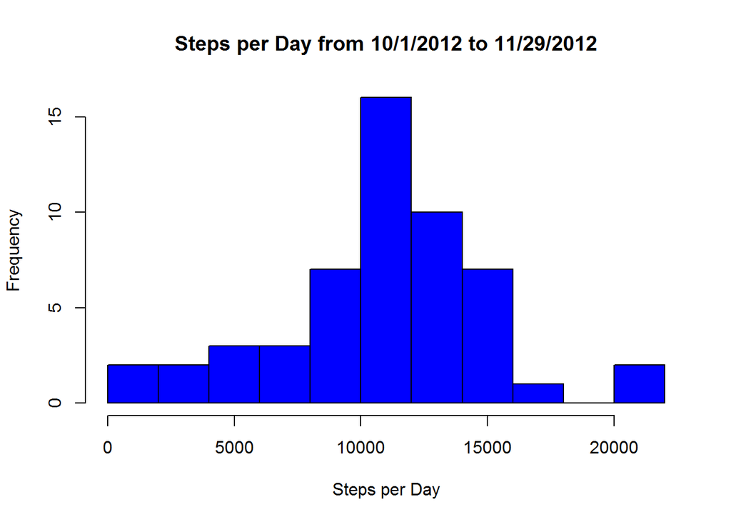

```r
hist(stepsperday$steps, breaks = 15, xlab = "Steps per Day", ylab ="Frequency", main = "Steps per Day from 10/1/2012 to 11/29/2012", col = "blue")
```

The mean number of steps per day is calculated below using the following code

```r
mean <- mean(stepsperday$steps, na.rm=FALSE)
mean
```

```
## [1] 10766.19
```

The median number of steps per day is calculated below using the follow code

```r
median <- median(stepsperday$steps, na.rm=FALSE)
median
```

```
## [1] 10765
```

## What is the average daily activity pattern?

Make a time series plot of the 5-minute interval (x-axis) and the average number of steps taken, averaged all days.

So in order to do this, the best strategy is to take the aggregated mean of the steps per interval and is shown in the R code below:

```r
meanstepsinterval <- aggregate(x=list(meanSteps=activity$steps), by=list(interval=activity$interval), FUN=mean, na.rm=TRUE)
```

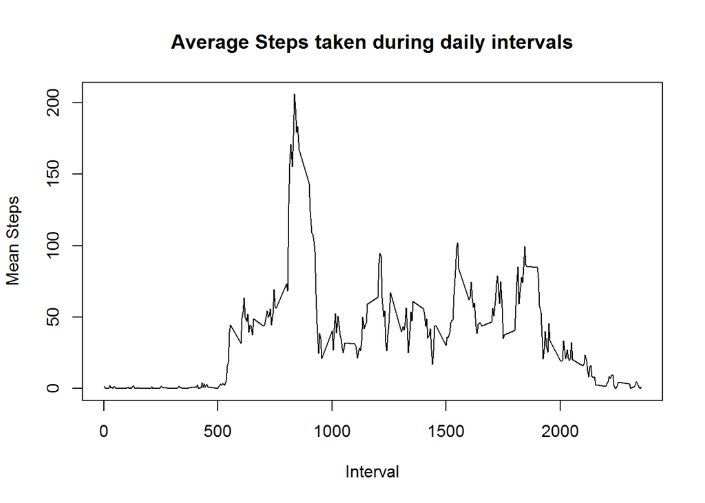

```r
plot(meanstepsinterval$interval, meanstepsinterval$meanSteps, type = "l", xlab = "Interval", ylab ="Mean Steps", main = "Average Steps taken during daily intervals")
```

What 5 minute interval contains the most steps per interval. In other words, which interval has the highest mean.

[output not shown]

This is a round about way, but here is the interval:

```r
max[288,]
```

```
##     interval meanSteps
## 104      835  206.1698
```

So the interval with the most steps on average is 8:35AM with ~206 steps on average in this interval. This corresponds to the peak in the figure above

## Imputing missing values

Let;s take a look at how many NAs there are in the “activity” data set:

```r
summary(activity)
```

```
##      steps            date              interval
##  Min.   :  0.00   Length:17568       Min.   :   0.0
##  1st Qu.:  0.00   Class :character   1st Qu.: 588.8
##  Median :  0.00   Mode  :character   Median :1177.5
##  Mean   : 37.38                      Mean   :1177.5
##  3rd Qu.: 12.00                      3rd Qu.:1766.2
##  Max.   :806.00                      Max.   :2355.0
##  NA's   :2304
```

If you look at the “steps” summary, we see there are 2304 NAs in the data set

Creating a new data set with NAs filled in:

```r
imvals <- meanstepsinterval
names(imvals)[2] <- "activitylabels"
completeactivity <- merge(activity, imvals)
completeactivity$steps[is.na(completeactivity$steps)] <- completeactivity$activitylabels[is.na(completeactivity$steps)]
head(completeactivity)
```

```
##   interval    steps       date activitylabels
## 1        0 1.716981 2012-10-01       1.716981
## 2        0 0.000000 2012-11-23       1.716981
## 3        0 0.000000 2012-10-28       1.716981
## 4        0 0.000000 2012-11-06       1.716981
## 5        0 0.000000 2012-11-24       1.716981
## 6        0 0.000000 2012-11-15       1.716981
```

Histogram of the full data set

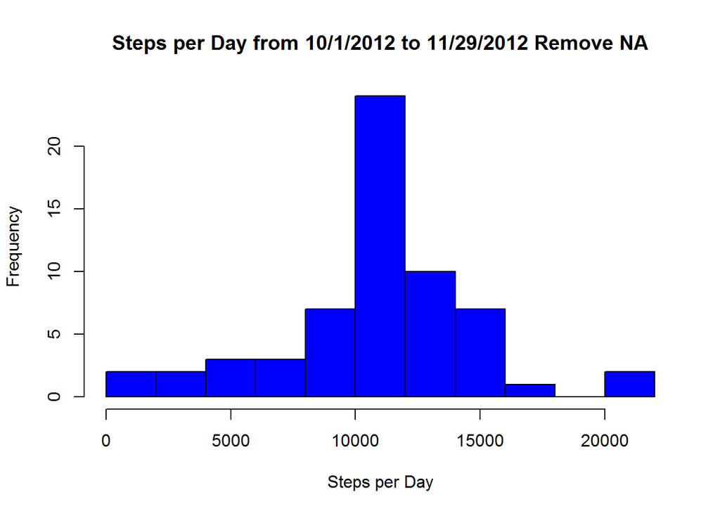

```r
completeactivitystepsperday <- aggregate(steps ~ date, completeactivity, sum)
hist(completeactivitystepsperday$steps, breaks = 15, xlab = "Steps per Day", ylab ="Frequency", main = "Steps per Day from 10/1/2012 to 11/29/2012 Remove NA", col = "blue")
```

Calculating the mean of the data set:

```r
completeactivitymean <- mean(completeactivitystepsperday$steps)
completeactivitymean
```

```
## [1] 10766.19
```

Calculating the median of the data set:

```r
completeactivitymedian <- median(completeactivitystepsperday$steps)
completeactivitymedian
```

```
## [1] 10766.19
```

As you can see, the median and the mean become the same when the mean is used to fill in the interval

## Are there differences in activity patterns between the weekdays and weekends

Create a factor variable with two levels “weekday” and “weekend”

```r
completeactivity$datetype <- ifelse(as.POSIXlt(completeactivity$date)$wday %in% c(0,6), 'weekend','weekday')
head(completeactivity)
```

```
##   interval    steps       date activitylabels datetype
## 1        0 1.716981 2012-10-01       1.716981  weekday
## 2        0 0.000000 2012-11-23       1.716981  weekday
## 3        0 0.000000 2012-10-28       1.716981  weekend
## 4        0 0.000000 2012-11-06       1.716981  weekday
## 5        0 0.000000 2012-11-24       1.716981  weekend
## 6        0 0.000000 2012-11-15       1.716981  weekday
```

This creates the new variable called “datetype”

Now the weekday and weekend need to be subsetted to be aggregated:

```r
weekday <- completeactivity[completeactivity$datetype == "weekday",]
weekend <- completeactivity[completeactivity$datetype =="weekend",]
```

Now need to compare the subsets weekday and weekend by aggregating the intervals (note this can be done with ggplot2, however, due to recent update in R, the package is not working so the base plotting system is used)

```r
weekdayinterval <- aggregate(x=list(meansteps=weekday$steps), by=list(interval=weekday$interval), FUN=mean, na.rm=TRUE)

weekendinterval <- aggregate(x=list(meansteps=weekend$steps), by=list(interval=weekend$interval), FUN=mean, na.rm=TRUE)
```

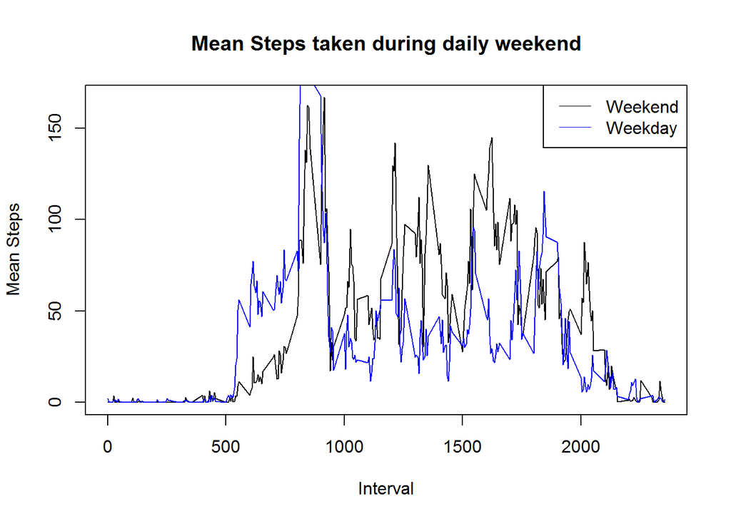

```r
par(mfrow = c(1,1))
plot(weekendinterval$interval, weekendinterval$meansteps, type = "l", xlab = "Interval", ylab ="Mean Steps", main = "Mean Steps taken during daily weekend")
lines(weekdayinterval$interval, weekdayinterval$meansteps, col="blue")
legend("topright", c("Weekend","Weekday"), lty=1, lwd=0.5, col=c("black","blue"))
```

Here is a panel plot of the weekend vs weekday side by side:

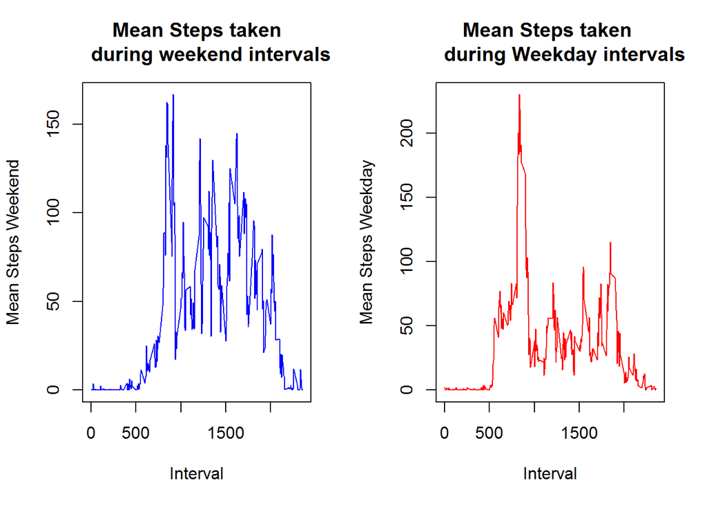

```r
par(mfrow = c(1,2))

plot(weekendinterval$interval, weekendinterval$meansteps, type = "l", xlab = "Interval", ylab ="Mean Steps Weekend", main = "Mean Steps taken
     during weekend intervals", col="blue")

plot(weekdayinterval$interval, weekdayinterval$meansteps, type = "l", xlab = "Interval", ylab ="Mean Steps Weekday", main = "Mean Steps taken
     during Weekday intervals", col="red")
```